# FB-PROPHET

# VAR model for forecasting

## Import Required Library

```python
import pandas as pd
import numpy as np
import warnings
warnings.filterwarnings('ignore')
import matplotlib.pyplot as plt
```

### Load the Dataset

```python
df = pd.read_excel('Dataset1.xlsx')
```

```python
df.head()
```

|  | Area | Year | Month | Involuntary | Voluntary | Total |
| --- | --- | --- | --- | --- | --- | --- |
| 0 | Unknown | 2017 Jul | Jul | 2 | 1 | 3 |
| 1 | Unknown | 2017 Aug | Aug | 10 | 2 | 12 |
| 2 | Unknown | 2017 Sep | Sep | 0 | 3 | 3 |
| 3 | Unknown | 2017 Oct | Oct | 0 | 5 | 5 |
| 4 | Unknown | 2017 Nov | Nov | 0 | 6 | 6 |

```python
df.shape
```

```
(225, 6)
```

```python
df.info() #check the basic information
```

```
<class 'pandas.core.frame.DataFrame'>
RangeIndex: 225 entries, 0 to 224
Data columns (total 6 columns):
 #   Column       Non-Null Count  Dtype
---  ------       --------------  -----
 0   Area         225 non-null    object
 1   Year         225 non-null    object
 2   Month        225 non-null    object
 3   Involuntary  225 non-null    int64
 4   Voluntary    225 non-null    int64
 5   Total        225 non-null    int64
dtypes: int64(3), object(3)
memory usage: 10.7+ KB
```

```python
df.describe() #check the basic statistics information
```

|  | Involuntary | Voluntary | Total |
| --- | --- | --- | --- |
| count | 225.000000 | 225.000000 | 225.000000 |
| mean | 28.728889 | 34.555556 | 63.284444 |
| std | 38.734701 | 48.193877 | 71.908293 |
| min | 0.000000 | 0.000000 | 1.000000 |
| 25% | 3.000000 | 4.000000 | 8.000000 |
| 50% | 16.000000 | 14.000000 | 37.000000 |
| 75% | 38.000000 | 36.000000 | 92.000000 |
| max | 267.000000 | 208.000000 | 316.000000 |

```python
df.isnull().sum() # check the null values
```

```
Area           0
Year           0
Month          0
Involuntary    0
Voluntary      0
Total          0
dtype: int64
```

```python
# df['Years']= df["Month"] + df["Year"].astype(str)
```

```python
df['Year'] = pd.to_datetime(df['Year'])
```

```python
df = df[["Year","Involuntary","Voluntary"]]
```

```python
df.info()
```

```
<class 'pandas.core.frame.DataFrame'>
RangeIndex: 225 entries, 0 to 224
Data columns (total 3 columns):
 #   Column       Non-Null Count  Dtype
---  ------       --------------  -----
 0   Year         225 non-null    datetime64[ns]
 1   Involuntary  225 non-null    int64
 2   Voluntary    225 non-null    int64
dtypes: datetime64[ns](1), int64(2)
memory usage: 5.4 KB
```

```python
df = df.fillna(0)
```

```python
df = df.loc[:224 ] # clean dataset
df
```

|  | Year | Involuntary | Voluntary |
| --- | --- | --- | --- |
| 0 | 2017-07-01 | 2 | 1 |
| 1 | 2017-08-01 | 10 | 2 |
| 2 | 2017-09-01 | 0 | 3 |
| 3 | 2017-10-01 | 0 | 5 |
| 4 | 2017-11-01 | 0 | 6 |
| ... | ... | ... | ... |
| 220 | 2021-02-01 | 0 | 1 |
| 221 | 2021-03-01 | 3 | 1 |
| 222 | 2021-05-01 | 1 | 0 |
| 223 | 2021-06-01 | 0 | 1 |
| 224 | 2021-07-01 | 154 | 1 |

225 rows × 3 columns

```python
df.set_index('Year',inplace = True)
```

```python
df
```

| Year | Involuntary | Voluntary |
| --- | --- | --- |
| 2017-07-01 | 2 | 1 |
| 2017-08-01 | 10 | 2 |
| 2017-09-01 | 0 | 3 |
| 2017-10-01 | 0 | 5 |
| 2017-11-01 | 0 | 6 |
| ... | ... | ... |
| 2021-02-01 | 0 | 1 |
| 2021-03-01 | 3 | 1 |
| 2021-05-01 | 1 | 0 |
| 2021-06-01 | 0 | 1 |
| 2021-07-01 | 154 | 1 |

225 rows × 2 columns

## Aggregate the dataset

```python
pd.pivot_table(df, values=['Involuntary', 'Voluntary'], index='Year',
                   aggfunc={'Involuntary': np.sum,'Voluntary': np.sum})
```

| Year | Involuntary | Voluntary |
| --- | --- | --- |
| 2017-07-01 | 76 | 119 |
| 2017-08-01 | 50 | 30 |
| 2017-09-01 | 42 | 152 |
| 2017-10-01 | 57 | 121 |
| 2017-11-01 | 141 | 120 |
| 2017-12-01 | 31 | 127 |
| 2018-01-01 | 34 | 100 |
| 2018-02-01 | 173 | 106 |
| 2018-03-01 | 44 | 122 |
| 2018-04-01 | 37 | 122 |
| 2018-05-01 | 39 | 117 |
| 2018-06-01 | 58 | 92 |
| 2018-07-01 | 54 | 108 |
| 2018-08-01 | 64 | 84 |
| 2018-09-01 | 147 | 168 |
| 2018-10-01 | 108 | 161 |
| 2018-11-01 | 103 | 132 |
| 2018-12-01 | 58 | 158 |
| 2019-01-01 | 91 | 130 |
| 2019-02-01 | 338 | 138 |
| 2019-03-01 | 449 | 117 |
| 2019-04-01 | 104 | 168 |
| 2019-05-01 | 187 | 144 |
| 2019-06-01 | 122 | 127 |
| 2019-07-01 | 146 | 176 |
| 2019-08-01 | 203 | 144 |
| 2019-09-01 | 137 | 210 |
| 2019-10-01 | 149 | 226 |
| 2019-11-01 | 142 | 197 |
| 2019-12-01 | 103 | 169 |
| 2020-01-01 | 120 | 195 |
| 2020-02-01 | 212 | 184 |
| 2020-03-01 | 123 | 156 |
| 2020-04-01 | 155 | 139 |
| 2020-05-01 | 51 | 113 |
| 2020-06-01 | 127 | 123 |
| 2020-07-01 | 136 | 157 |
| 2020-08-01 | 297 | 175 |
| 2020-09-01 | 101 | 238 |
| 2020-10-01 | 158 | 203 |
| 2020-11-01 | 111 | 213 |
| 2020-12-01 | 134 | 228 |
| 2021-01-01 | 127 | 209 |
| 2021-02-01 | 167 | 236 |
| 2021-03-01 | 93 | 245 |
| 2021-04-01 | 73 | 251 |
| 2021-05-01 | 75 | 212 |
| 2021-06-01 | 341 | 201 |
| 2021-07-01 | 376 | 212 |

```python
df1 = df.groupby('Year').aggregate({'Involuntary': 'sum',
                             'Voluntary': 'sum'})
```

```python
df1
```

| Year | Involuntary | Voluntary |
| --- | --- | --- |
| 2017-07-01 | 76 | 119 |
| 2017-08-01 | 50 | 30 |
| 2017-09-01 | 42 | 152 |
| 2017-10-01 | 57 | 121 |
| 2017-11-01 | 141 | 120 |
| 2017-12-01 | 31 | 127 |
| 2018-01-01 | 34 | 100 |
| 2018-02-01 | 173 | 106 |
| 2018-03-01 | 44 | 122 |
| 2018-04-01 | 37 | 122 |
| 2018-05-01 | 39 | 117 |
| 2018-06-01 | 58 | 92 |
| 2018-07-01 | 54 | 108 |
| 2018-08-01 | 64 | 84 |
| 2018-09-01 | 147 | 168 |
| 2018-10-01 | 108 | 161 |
| 2018-11-01 | 103 | 132 |
| 2018-12-01 | 58 | 158 |
| 2019-01-01 | 91 | 130 |
| 2019-02-01 | 338 | 138 |
| 2019-03-01 | 449 | 117 |
| 2019-04-01 | 104 | 168 |
| 2019-05-01 | 187 | 144 |
| 2019-06-01 | 122 | 127 |
| 2019-07-01 | 146 | 176 |
| 2019-08-01 | 203 | 144 |
| 2019-09-01 | 137 | 210 |
| 2019-10-01 | 149 | 226 |
| 2019-11-01 | 142 | 197 |
| 2019-12-01 | 103 | 169 |
| 2020-01-01 | 120 | 195 |
| 2020-02-01 | 212 | 184 |
| 2020-03-01 | 123 | 156 |
| 2020-04-01 | 155 | 139 |
| 2020-05-01 | 51 | 113 |
| 2020-06-01 | 127 | 123 |
| 2020-07-01 | 136 | 157 |
| 2020-08-01 | 297 | 175 |
| 2020-09-01 | 101 | 238 |
| 2020-10-01 | 158 | 203 |
| 2020-11-01 | 111 | 213 |
| 2020-12-01 | 134 | 228 |
| 2021-01-01 | 127 | 209 |
| 2021-02-01 | 167 | 236 |
| 2021-03-01 | 93 | 245 |
| 2021-04-01 | 73 | 251 |
| 2021-05-01 | 75 | 212 |
| 2021-06-01 | 341 | 201 |
| 2021-07-01 | 376 | 212 |

## Data Visualization

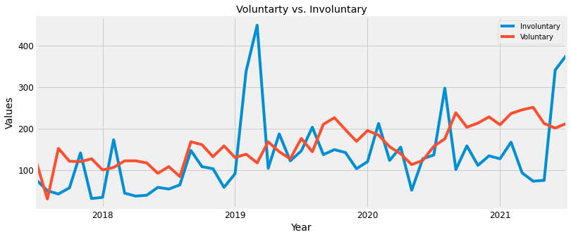

```python
title = 'Voluntarty vs. Involuntary'
ylabel='Values'
xlabel=''
ax = df1['Involuntary'].plot(figsize=(12,5),title=title,legend=True)
ax.autoscale(axis='x',tight=True)
ax.set(xlabel=xlabel, ylabel=ylabel)
df1['Voluntary'].plot(legend=True)
plt.show()
```

```python
df1.info()
```

```
<class 'pandas.core.frame.DataFrame'>
DatetimeIndex: 49 entries, 2017-07-01 to 2021-07-01
Data columns (total 2 columns):
 #   Column       Non-Null Count  Dtype
---  ------       --------------  -----
 0   Involuntary  49 non-null     int64
 1   Voluntary    49 non-null     int64
dtypes: int64(2)
memory usage: 1.1 KB
```

```python
df1.columns
```

```
Index(['Involuntary', 'Voluntary'], dtype='object')
```

```python
import matplotlib.pyplot as plt
```

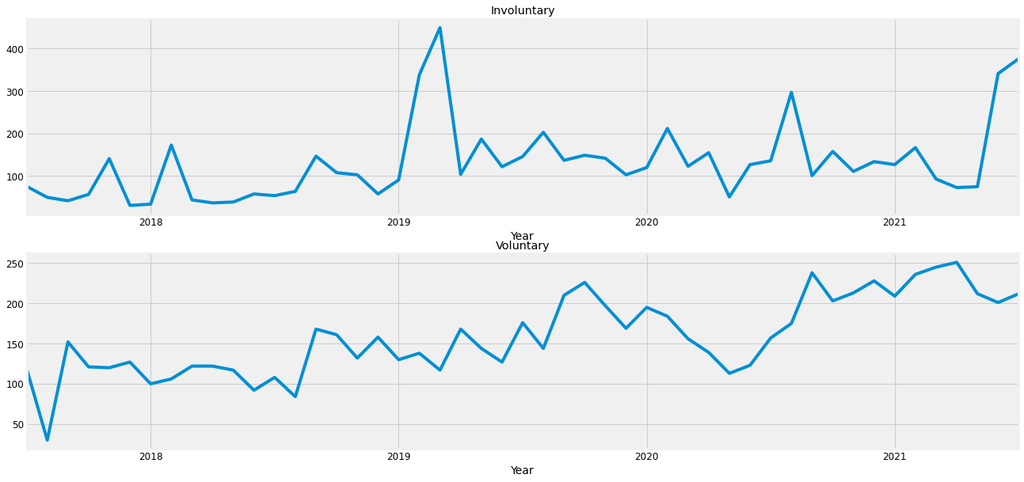

```python
fig,ax = plt.subplots(2,1,figsize=(20,10))
for i,column in enumerate([col for col in df1.columns]):
    df1[column].plot(ax=ax[i])
    ax[i].set_title(column)
```

### Autocorrelation plot

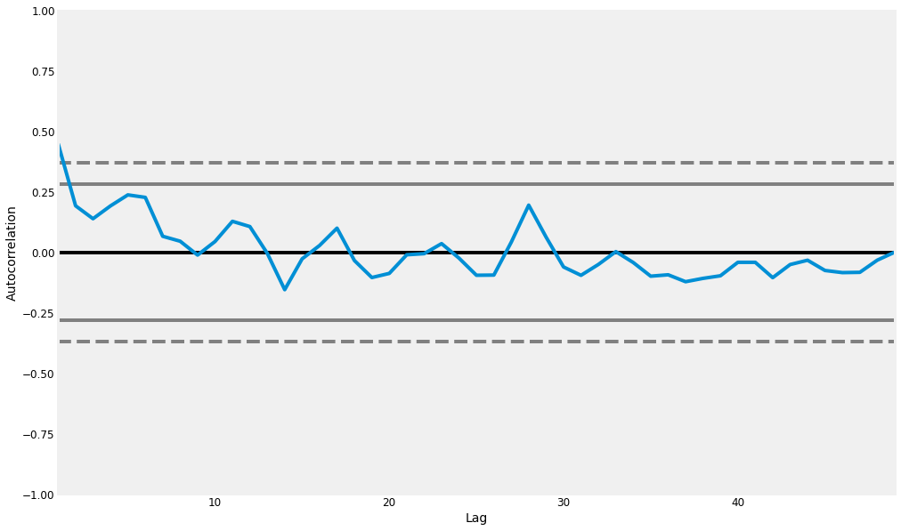

```python
from pandas.plotting import autocorrelation_plot
from matplotlib.pylab import rcParams
# rcParams['figure.figsize'] = 10,6
rcParams['figure.figsize'] = 15,10
autocorrelation_plot(df1)
plt.show()
```

```python
def adf_test(series,title=''):
    """
    Pass in a time series and an optional title, returns an ADF report
    """
    print(f'Augmented Dickey-Fuller Test: {title}')
    result = adfuller(series.dropna(),autolag='AIC') # .dropna() handles differenced data

    labels = ['ADF test statistic','p-value','# lags used','# observations']
    out = pd.Series(result[0:4],index=labels)

    for key,val in result[4].items():
        out[f'critical value ({key})']=val

    print(out.to_string())          # .to_string() removes the line "dtype: float64"

    if result[1] <= 0.05:
        print("Strong evidence against the null hypothesis")
        print("Reject the null hypothesis")
        print("Data has no unit root and is stationary")
    else:
        print("Weak evidence against the null hypothesis")
        print("Fail to reject the null hypothesis")
        print("Data has a unit root and is non-stationary")
```

## Model part

### VAR (Vector autoregression)

```python
%matplotlib inline
# Load specific forecasting tools
from statsmodels.tsa.api import VAR
from statsmodels.tsa.stattools import adfuller
from statsmodels.tools.eval_measures import rmse
```

```python
adf_test(df1['Involuntary'],title='Involuntary')
```

```
Augmented Dickey-Fuller Test: Involuntary
ADF test statistic      -4.006374
p-value                  0.001377
# lags used              0.000000
# observations          48.000000
critical value (1%)     -3.574589
critical value (5%)     -2.923954
critical value (10%)    -2.600039
Strong evidence against the null hypothesis
Reject the null hypothesis
Data has no unit root and is stationary
```

```python
adf_test(df1['Voluntary'],title='voluntary')
```

```
Augmented Dickey-Fuller Test: voluntary
ADF test statistic      -2.664515
p-value                  0.080382
# lags used              0.000000
# observations          48.000000
critical value (1%)     -3.574589
critical value (5%)     -2.923954
critical value (10%)    -2.600039
Weak evidence against the null hypothesis
Fail to reject the null hypothesis
Data has a unit root and is non-stationary
```

```python
nobs=12
train, test = df1[0:-nobs], df1[-nobs:]
```

```python
test
```

| Year | Involuntary | Voluntary |
| --- | --- | --- |
| 2020-08-01 | 297 | 175 |
| 2020-09-01 | 101 | 238 |
| 2020-10-01 | 158 | 203 |
| 2020-11-01 | 111 | 213 |
| 2020-12-01 | 134 | 228 |
| 2021-01-01 | 127 | 209 |
| 2021-02-01 | 167 | 236 |
| 2021-03-01 | 93 | 245 |
| 2021-04-01 | 73 | 251 |
| 2021-05-01 | 75 | 212 |
| 2021-06-01 | 341 | 201 |
| 2021-07-01 | 376 | 212 |

```python
train
```

| Year | Involuntary | Voluntary |
| --- | --- | --- |
| 2017-07-01 | 76 | 119 |
| 2017-08-01 | 50 | 30 |
| 2017-09-01 | 42 | 152 |
| 2017-10-01 | 57 | 121 |
| 2017-11-01 | 141 | 120 |
| 2017-12-01 | 31 | 127 |
| 2018-01-01 | 34 | 100 |
| 2018-02-01 | 173 | 106 |
| 2018-03-01 | 44 | 122 |
| 2018-04-01 | 37 | 122 |
| 2018-05-01 | 39 | 117 |
| 2018-06-01 | 58 | 92 |
| 2018-07-01 | 54 | 108 |
| 2018-08-01 | 64 | 84 |
| 2018-09-01 | 147 | 168 |
| 2018-10-01 | 108 | 161 |
| 2018-11-01 | 103 | 132 |
| 2018-12-01 | 58 | 158 |
| 2019-01-01 | 91 | 130 |
| 2019-02-01 | 338 | 138 |
| 2019-03-01 | 449 | 117 |
| 2019-04-01 | 104 | 168 |
| 2019-05-01 | 187 | 144 |
| 2019-06-01 | 122 | 127 |
| 2019-07-01 | 146 | 176 |
| 2019-08-01 | 203 | 144 |
| 2019-09-01 | 137 | 210 |
| 2019-10-01 | 149 | 226 |
| 2019-11-01 | 142 | 197 |
| 2019-12-01 | 103 | 169 |
| 2020-01-01 | 120 | 195 |
| 2020-02-01 | 212 | 184 |
| 2020-03-01 | 123 | 156 |
| 2020-04-01 | 155 | 139 |
| 2020-05-01 | 51 | 113 |
| 2020-06-01 | 127 | 123 |
| 2020-07-01 | 136 | 157 |

```python
print(train.shape)
print(test.shape)
```

```
(37, 2)
(12, 2)
```

```python
from statsmodels.tsa.api import VAR
```

```python
for i in [1,2,3,4,5,6,7]:
    model = VAR(train)
    results = model.fit(i)
    print('Order =', i)
    print('AIC: ', results.aic)
    print('BIC: ', results.bic)
    print()
```

```
Order = 1
AIC:  15.926989922057201
BIC:  16.19090974513322

Order = 2
AIC:  15.7944670732544
BIC:  16.238852233679946

Order = 3
AIC:  15.93093721724469
BIC:  16.559438609733697

Order = 4
AIC:  16.15668126053112
BIC:  16.97295811224011

Order = 5
AIC:  16.294073843859298
BIC:  17.30176727703411

Order = 6
AIC:  16.401733022293826
BIC:  17.604431967991044

Order = 7
AIC:  16.324539011928024
BIC:  17.72573639359018
```

```python
model = VAR(train)
for i in [1,2,3,4,5,6,7]:
    results = model.fit(i)
    print('Order =', i)
    print('AIC: ', results.aic)
    print('BIC: ', results.bic)
    print()
```

```
Order = 1
AIC:  15.926989922057201
BIC:  16.19090974513322

Order = 2
AIC:  15.7944670732544
BIC:  16.238852233679946

Order = 3
AIC:  15.93093721724469
BIC:  16.559438609733697

Order = 4
AIC:  16.15668126053112
BIC:  16.97295811224011

Order = 5
AIC:  16.294073843859298
BIC:  17.30176727703411

Order = 6
AIC:  16.401733022293826
BIC:  17.604431967991044

Order = 7
AIC:  16.324539011928024
BIC:  17.72573639359018
```

```python
model.endog_names
```

```
['Involuntary', 'Voluntary']
```

## Model Summary

```python
results = model.fit(5)
results.summary()
```

```
  Summary of Regression Results
==================================
Model:                         VAR
Method:                        OLS
Date:           Wed, 30, Mar, 2022
Time:                     17:38:11
--------------------------------------------------------------------
No. of Equations:         2.00000    BIC:                    17.3018
Nobs:                     32.0000    HQIC:                   16.6281
Log likelihood:          -329.517    FPE:                1.26407e+07
AIC:                      16.2941    Det(Omega_mle):     7.00056e+06
--------------------------------------------------------------------
Results for equation Involuntary
=================================================================================
                    coefficient       std. error           t-stat            prob
---------------------------------------------------------------------------------
const                -13.968719        83.747571           -0.167           0.868
L1.Involuntary         0.281118         0.203128            1.384           0.166
L1.Voluntary           0.414484         0.650791            0.637           0.524
L2.Involuntary        -0.114261         0.213042           -0.536           0.592
L2.Voluntary          -0.345284         0.712273           -0.485           0.628
L3.Involuntary         0.036835         0.224196            0.164           0.869
L3.Voluntary          -0.362067         0.679201           -0.533           0.594
L4.Involuntary        -0.019378         0.225499           -0.086           0.932
L4.Voluntary           0.206511         0.518671            0.398           0.691
L5.Involuntary         0.165209         0.213202            0.775           0.438
L5.Voluntary           0.790417         0.506660            1.560           0.119
=================================================================================

Results for equation Voluntary
=================================================================================
                    coefficient       std. error           t-stat            prob
---------------------------------------------------------------------------------
const                 42.892497        28.171902            1.523           0.128
L1.Involuntary         0.047210         0.068330            0.691           0.490
L1.Voluntary           0.464854         0.218920            2.123           0.034
L2.Involuntary         0.055298         0.071665            0.772           0.440
L2.Voluntary           0.170414         0.239602            0.711           0.477
L3.Involuntary        -0.056972         0.075418           -0.755           0.450
L3.Voluntary          -0.052971         0.228477           -0.232           0.817
L4.Involuntary         0.037198         0.075856            0.490           0.624
L4.Voluntary          -0.122883         0.174476           -0.704           0.481
L5.Involuntary         0.061374         0.071719            0.856           0.392
L5.Voluntary           0.126960         0.170436            0.745           0.456
=================================================================================

Correlation matrix of residuals
               Involuntary  Voluntary
Involuntary       1.000000  -0.063608
Voluntary        -0.063608   1.000000
```

```python
lag_order = results.k_ar
lag_order
```

```
5
```

```python
z = results.forecast(y=train.values[-lag_order:], steps=12)
z
```

```
array([[162.64842831, 157.42729769],
       [145.22327132, 159.44819803],
       [ 88.85106145, 150.71194502],
       [ 98.80989501, 143.92026286],
       [134.81145871, 143.32070841],
       [152.47271592, 148.60263952],
       [156.5529987 , 151.73651011],
       [138.88642811, 149.87941982],
       [125.79573623, 148.81759443],
       [129.57346714, 148.15547247],
       [139.90587856, 149.74728937],
       [146.27950324, 152.09251324]])
```

```python
test
```

| Year | Involuntary | Voluntary |
| --- | --- | --- |
| 2020-08-01 | 297 | 175 |
| 2020-09-01 | 101 | 238 |
| 2020-10-01 | 158 | 203 |
| 2020-11-01 | 111 | 213 |
| 2020-12-01 | 134 | 228 |
| 2021-01-01 | 127 | 209 |
| 2021-02-01 | 167 | 236 |
| 2021-03-01 | 93 | 245 |
| 2021-04-01 | 73 | 251 |
| 2021-05-01 | 75 | 212 |
| 2021-06-01 | 341 | 201 |
| 2021-07-01 | 376 | 212 |

## Forecasting values

```python
idx = pd.date_range('2021-07-02', periods=12, freq='MS')
df_forecast = pd.DataFrame(z, index=idx, columns=['Involuntary_F','Voluntary_F'])
df_forecast
```

|  | Involuntary_F | Voluntary_F |
| --- | --- | --- |
| 2021-08-01 | 162.648428 | 157.427298 |
| 2021-09-01 | 145.223271 | 159.448198 |
| 2021-10-01 | 88.851061 | 150.711945 |
| 2021-11-01 | 98.809895 | 143.920263 |
| 2021-12-01 | 134.811459 | 143.320708 |
| 2022-01-01 | 152.472716 | 148.602640 |
| 2022-02-01 | 156.552999 | 151.736510 |
| 2022-03-01 | 138.886428 | 149.879420 |
| 2022-04-01 | 125.795736 | 148.817594 |
| 2022-05-01 | 129.573467 | 148.155472 |
| 2022-06-01 | 139.905879 | 149.747289 |
| 2022-07-01 | 146.279503 | 152.092513 |

```python
df_forecast['InVol'] = (df['Involuntary'].iloc[-nobs-1]-df['Involuntary'].iloc[-nobs-2]) + df_forecast['Involuntary_F'].cumsum()

# Now build the forecast values from the first difference set
df_forecast['InvolForecast'] = df['Involuntary'].iloc[-nobs-1] + df_forecast['InVol'].cumsum()
```

```python
df_forecast['Vol'] = (df['Voluntary'].iloc[-nobs-1]-df['Voluntary'].iloc[-nobs-2]) + df_forecast['Voluntary_F'].cumsum()

# Now build the forecast values from the first difference set
df_forecast['VolForecast'] = df['Voluntary'].iloc[-nobs-1] + df_forecast['Vol'].cumsum()
```

```python
df_forecast
```

|  | Involuntary_F | Voluntary_F | InVol | InvolForecast | Vol | VolForecast |
| --- | --- | --- | --- | --- | --- | --- |
| 2021-08-01 | 162.648428 | 157.427298 | 162.648428 | 163.648428 | 158.427298 | 160.427298 |
| 2021-09-01 | 145.223271 | 159.448198 | 307.871700 | 471.520128 | 317.875496 | 478.302793 |
| 2021-10-01 | 88.851061 | 150.711945 | 396.722761 | 868.242889 | 468.587441 | 946.890234 |
| 2021-11-01 | 98.809895 | 143.920263 | 495.532656 | 1363.775545 | 612.507704 | 1559.397938 |
| 2021-12-01 | 134.811459 | 143.320708 | 630.344115 | 1994.119660 | 755.828412 | 2315.226350 |
| 2022-01-01 | 152.472716 | 148.602640 | 782.816831 | 2776.936491 | 904.431052 | 3219.657401 |
| 2022-02-01 | 156.552999 | 151.736510 | 939.369829 | 3716.306320 | 1056.167562 | 4275.824963 |
| 2022-03-01 | 138.886428 | 149.879420 | 1078.256258 | 4794.562578 | 1206.046981 | 5481.871944 |
| 2022-04-01 | 125.795736 | 148.817594 | 1204.051994 | 5998.614571 | 1354.864576 | 6836.736520 |
| 2022-05-01 | 129.573467 | 148.155472 | 1333.625461 | 7332.240032 | 1503.020048 | 8339.756569 |
| 2022-06-01 | 139.905879 | 149.747289 | 1473.531339 | 8805.771372 | 1652.767338 | 9992.523906 |
| 2022-07-01 | 146.279503 | 152.092513 | 1619.810843 | 10425.582214 | 1804.859851 | 11797.383757 |

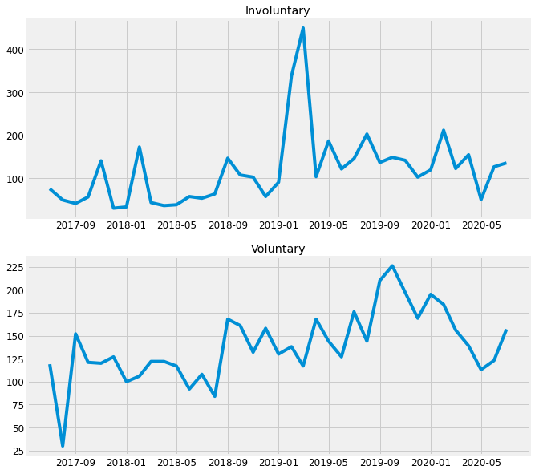

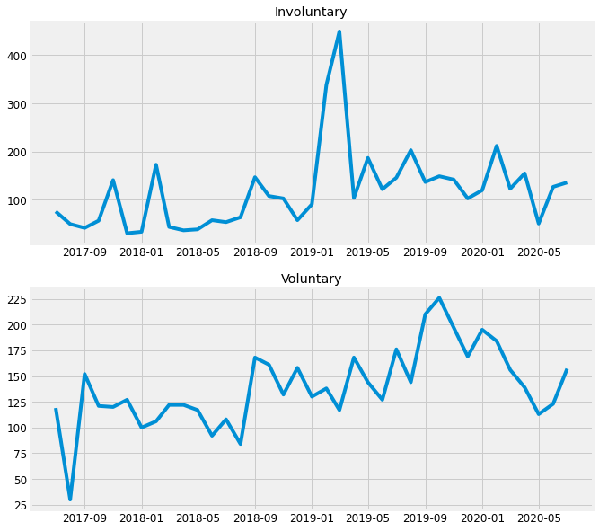

```python
results.plot()
```

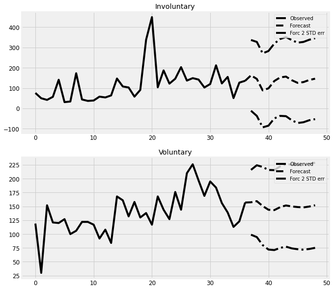

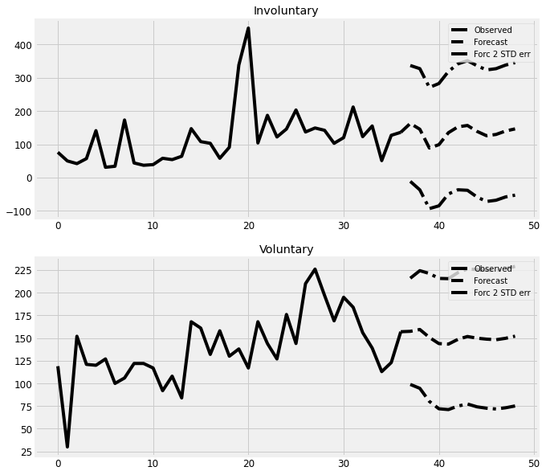

```python
results.plot_forecast(12)
```

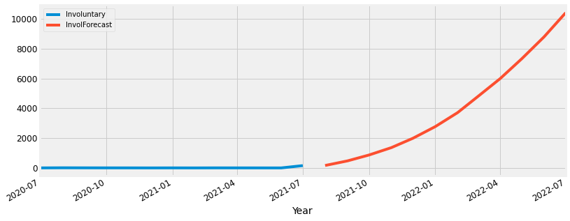

```python
df['Involuntary'][-nobs:].plot(figsize=(12,5),legend=True).autoscale(axis='x',tight=True)
df_forecast['InvolForecast'].plot(legend=True);
```

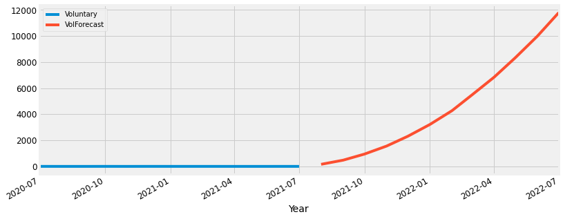

```python
df['Voluntary'][-nobs:].plot(figsize=(12,5),legend=True).autoscale(axis='x',tight=True)
df_forecast['VolForecast'].plot(legend=True);
```

```python
RMSE1 = rmse(df['Involuntary'][-nobs:], df_forecast['InvolForecast'])
print(f'Involuntary VAR(5) RMSE: {RMSE1:.3f}')
```

```
Involuntary VAR(5) RMSE: 5196.501
```

```python
RMSE2 = rmse(df['Voluntary'][-nobs:], df_forecast['VolForecast'])
print(f'Voluntary VAR(5) RMSE: {RMSE2:.3f}')
```

```
Voluntary VAR(5) RMSE: 5936.242
```

# Weather Forecasting using SRIMAX Model

### import required library

```python
# Import numpy, pandas for data manipulation
import numpy as np
import pandas as pd

# Import matplotlib, seaborn for visualization
import matplotlib.pyplot as plt
import seaborn as sns
import warnings
warnings.filterwarnings('ignore')
```

```python
# Import the data
weather_data = pd.read_csv('weather.csv')
weather_data.head()
```

|  | Date | Location | MinTemp | MaxTemp | Rainfall | Evaporation | Sunshine | WindGustDir | WindGustSpeed | WindDir9am | ... | Humidity9am | Humidity3pm | Pressure9am | Pressure3pm | Cloud9am | Cloud3pm | Temp9am | Temp3pm | RainToday | RainTomorrow |
| --- | --- | --- | --- | --- | --- | --- | --- | --- | --- | --- | --- | --- | --- | --- | --- | --- | --- | --- | --- | --- | --- |
| 0 | 2008-12-01 | Albury | 13.4 | 22.9 | 0.6 | NaN | NaN | W | 44.0 | W | ... | 71.0 | 22.0 | 1007.7 | 1007.1 | 8.0 | NaN | 16.9 | 21.8 | No | No |
| 1 | 2008-12-02 | Albury | 7.4 | 25.1 | 0.0 | NaN | NaN | WNW | 44.0 | NNW | ... | 44.0 | 25.0 | 1010.6 | 1007.8 | NaN | NaN | 17.2 | 24.3 | No | No |
| 2 | 2008-12-03 | Albury | 12.9 | 25.7 | 0.0 | NaN | NaN | WSW | 46.0 | W | ... | 38.0 | 30.0 | 1007.6 | 1008.7 | NaN | 2.0 | 21.0 | 23.2 | No | No |
| 3 | 2008-12-04 | Albury | 9.2 | 28.0 | 0.0 | NaN | NaN | NE | 24.0 | SE | ... | 45.0 | 16.0 | 1017.6 | 1012.8 | NaN | NaN | 18.1 | 26.5 | No | No |
| 4 | 2008-12-05 | Albury | 17.5 | 32.3 | 1.0 | NaN | NaN | W | 41.0 | ENE | ... | 82.0 | 33.0 | 1010.8 | 1006.0 | 7.0 | 8.0 | 17.8 | 29.7 | No | No |

5 rows × 23 columns

```python
rain_df = weather_data[['Date','Rainfall']]
rain_df.head()
```

|  | Date | Rainfall |
| --- | --- | --- |
| 0 | 2008-12-01 | 0.6 |
| 1 | 2008-12-02 | 0.0 |
| 2 | 2008-12-03 | 0.0 |
| 3 | 2008-12-04 | 0.0 |
| 4 | 2008-12-05 | 1.0 |

```python
rain_df.shape
```

```
(145460, 2)
```

```python
rain_df.info()
```

```
<class 'pandas.core.frame.DataFrame'>
RangeIndex: 145460 entries, 0 to 145459
Data columns (total 2 columns):
 #   Column    Non-Null Count   Dtype
---  ------    --------------   -----
 0   Date      145460 non-null  object
 1   Rainfall  142199 non-null  float64
dtypes: float64(1), object(1)
memory usage: 2.2+ MB
```

**Using 50 values**

```python
rain_df = rain_df.loc[:49]
rain_df.head()
```

|  | Date | Rainfall |
| --- | --- | --- |
| 0 | 2008-12-01 | 0.6 |
| 1 | 2008-12-02 | 0.0 |
| 2 | 2008-12-03 | 0.0 |
| 3 | 2008-12-04 | 0.0 |
| 4 | 2008-12-05 | 1.0 |

```python
rain_df.shape
```

```
(50, 2)
```

```python
# Convert the time column into datetime
rain_df['Date'] = pd.to_datetime(rain_df['Date'])
rain_df['Date'].head()
```

```
0   2008-12-01
1   2008-12-02
2   2008-12-03
3   2008-12-04
4   2008-12-05
Name: Date, dtype: datetime64[ns]
```

```python
rain_df.info()
```

```
<class 'pandas.core.frame.DataFrame'>
RangeIndex: 50 entries, 0 to 49
Data columns (total 2 columns):
 #   Column    Non-Null Count  Dtype
---  ------    --------------  -----
 0   Date      50 non-null     datetime64[ns]
 1   Rainfall  49 non-null     float64
dtypes: datetime64[ns](1), float64(1)
memory usage: 928.0 bytes
```

```python
# fill the empty row
rain_df = rain_df.fillna(rain_df['Rainfall'].mean())
rain_df.head()
```

|  | Date | Rainfall |
| --- | --- | --- |
| 0 | 2008-12-01 | 0.6 |
| 1 | 2008-12-02 | 0.0 |
| 2 | 2008-12-03 | 0.0 |
| 3 | 2008-12-04 | 0.0 |
| 4 | 2008-12-05 | 1.0 |

### Dataset Explanation

```python
rain_df.describe()
```

|  | Rainfall |
| --- | --- |
| count | 50.000000 |
| mean | 1.102041 |
| std | 3.504195 |
| min | 0.000000 |
| 25% | 0.000000 |
| 50% | 0.000000 |
| 75% | 0.000000 |
| max | 16.800000 |

```python
# Output the maximum and minimum rain date
print(rain_df.loc[rain_df["Rainfall"] == rain_df["Rainfall"].max()])
print(rain_df.loc[rain_df["Rainfall"] == rain_df["Rainfall"].min()])
```

```
         Date  Rainfall
17 2008-12-18      16.8
         Date  Rainfall
1  2008-12-02       0.0
2  2008-12-03       0.0
3  2008-12-04       0.0
6  2008-12-07       0.0
7  2008-12-08       0.0
8  2008-12-09       0.0
10 2008-12-11       0.0
14 2008-12-15       0.0
16 2008-12-17       0.0
19 2008-12-20       0.0
20 2008-12-21       0.0
21 2008-12-22       0.0
```

[output cut: 26 more lines]

```python
# Reset the index
rain_df.set_index("Date", inplace=True)
```

### Data Visualization

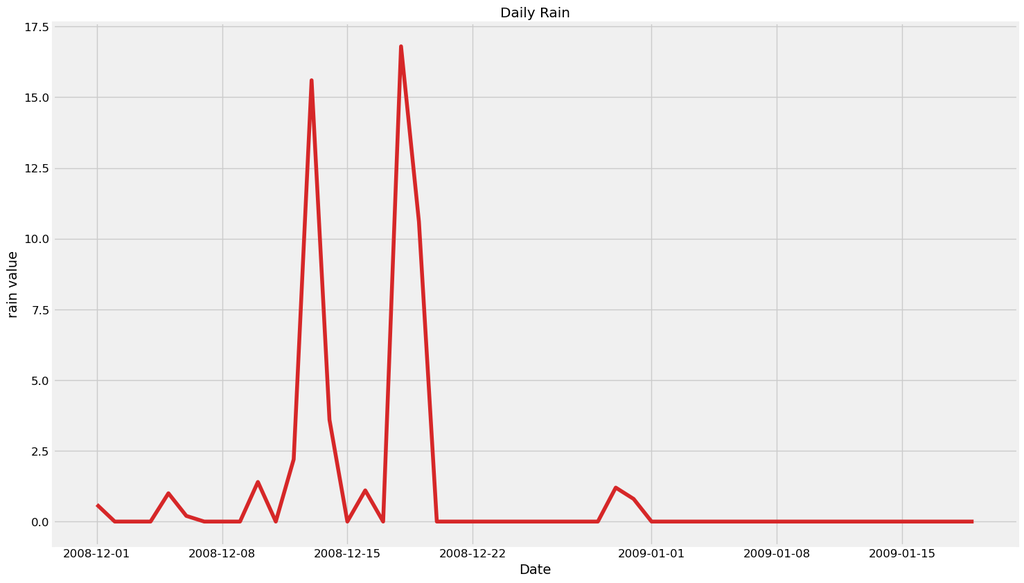

```python
# Plot the daily temperature change
plt.figure(figsize=(16,10), dpi=100)
plt.plot(rain_df.index, rain_df.Rainfall, color='tab:red')
plt.gca().set(title="Daily Rain", xlabel='Date', ylabel="rain value")
plt.show()
```

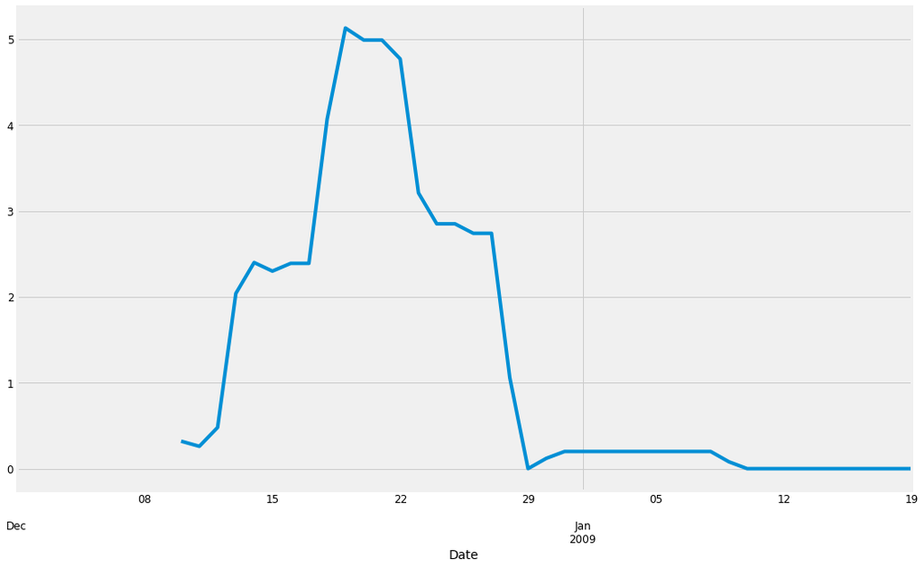

```python
# Apply the Moving Average function by a subset of size 10 days.
rain_df_mean = rain_df.Rainfall.rolling(window=10).mean()
rain_df_mean.plot(figsize=(16,10))
plt.show()
```

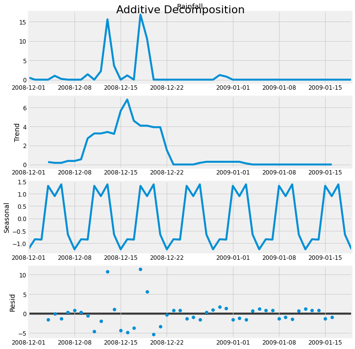

```python
from statsmodels.tsa.seasonal import seasonal_decompose

# Additive Decomposition
result_add = seasonal_decompose(rain_df.Rainfall, model='additive', extrapolate_trend=0)

# Plot
plt.rcParams.update({'figure.figsize': (10,10)})
result_add.plot().suptitle('Additive Decomposition', fontsize=22)
plt.show()
```

### Baseline Model

```python
# Shift the current rain to the next day.
predicted_df = rain_df["Rainfall"].to_frame().shift(1).rename(columns = {"Rainfall": "rain_pred" })
actual_df = rain_df["Rainfall"].to_frame().rename(columns = {"Rainfall": "rain_actual" })

# Concatenate the actual and predicted rain
one_step_df = pd.concat([actual_df,predicted_df],axis=1)

# Select from the second row, because there is no prediction for today due to shifting.
one_step_df = one_step_df[1:]
one_step_df.head(10)
```

| Date | rain_actual | rain_pred |
| --- | --- | --- |
| 2008-12-02 | 0.0 | 0.6 |
| 2008-12-03 | 0.0 | 0.0 |
| 2008-12-04 | 0.0 | 0.0 |
| 2008-12-05 | 1.0 | 0.0 |
| 2008-12-06 | 0.2 | 1.0 |
| 2008-12-07 | 0.0 | 0.2 |
| 2008-12-08 | 0.0 | 0.0 |
| 2008-12-09 | 0.0 | 0.0 |
| 2008-12-10 | 1.4 | 0.0 |
| 2008-12-11 | 0.0 | 1.4 |

> Here you can the we have two column one is our **actual rain** column and othe is **predicted rain** column that we use next model

We could validate how well our model is by looking at the Root Mean Squared Error(RMSE) between the predicted and actual rain

```python
from sklearn.metrics import mean_squared_error as MSE
from math import sqrt

# Calculate the RMSE
rain_pred_err = MSE(one_step_df.rain_actual, one_step_df.rain_pred, squared=False)
print("The RMSE is",rain_pred_err)
```

```
The RMSE is 4.002624108444867
```

## Using SARIMA model

### Parameter Selection

#### Grid Search

We are going to apply one of the most commonly used method for time-series forecasting, known as SARIMA, which stands for Seasonal Autoregressive Integrated Moving Average. SARIMA models are denoted with the notation SARIMA(p,d,q)(P,D,Q,s). These three parameters account for seasonality, trend, and noise in data:

We will use a “grid search” to iteratively explore different combinations of parameters. For each combination of parameters, we fit a new seasonal SARIMA model with the SARIMAX() function from the statsmodels module and assess its overall quality.

```python
import itertools

# Define the p, d and q parameters to take any value between 0 and 2
p = d = q = range(0, 2)

# Generate all different combinations of p, q and q triplets
pdq = list(itertools.product(p, d, q))

# Generate all different combinations of seasonal p, q and q triplets
seasonal_pdq = [(x[0], x[1], x[2], 12) for x in list(itertools.product(p, d, q))]

print('Examples of parameter combinations for Seasonal ARIMA...')
print('SARIMAX: {} x {}'.format(pdq[1], seasonal_pdq[1]))
print('SARIMAX: {} x {}'.format(pdq[1], seasonal_pdq[2]))
print('SARIMAX: {} x {}'.format(pdq[2], seasonal_pdq[3]))
print('SARIMAX: {} x {}'.format(pdq[2], seasonal_pdq[4]))
```

```
Examples of parameter combinations for Seasonal ARIMA...
SARIMAX: (0, 0, 1) x (0, 0, 1, 12)
SARIMAX: (0, 0, 1) x (0, 1, 0, 12)
SARIMAX: (0, 1, 0) x (0, 1, 1, 12)
SARIMAX: (0, 1, 0) x (1, 0, 0, 12)
```

```python
for param in pdq:
    for param_seasonal in seasonal_pdq:
        try:
            mod = sm.tsa.statespace.SARIMAX(one_step_df.rain_actual,
                                            order=param,
                                            seasonal_order=param_seasonal,
                                            enforce_stationarity=False,
                                            enforce_invertibility=False)

            results = mod.fit()

            print('SARIMA{}x{}12 - AIC:{}'.format(param, param_seasonal, results.aic))
        except:
            continue
```

```
SARIMA(0, 0, 0)x(0, 0, 0, 12)12 - AIC:264.1771484103642
SARIMA(0, 0, 0)x(0, 0, 1, 12)12 - AIC:192.10299334638094
SARIMA(0, 0, 0)x(0, 1, 0, 12)12 - AIC:223.68995002209397
SARIMA(0, 0, 0)x(0, 1, 1, 12)12 - AIC:123.40988892000172
SARIMA(0, 0, 0)x(1, 0, 0, 12)12 - AIC:197.93278338949165
SARIMA(0, 0, 0)x(1, 0, 1, 12)12 - AIC:190.68462528229279
SARIMA(0, 0, 0)x(1, 1, 0, 12)12 - AIC:130.82268967031777
SARIMA(0, 0, 0)x(1, 1, 1, 12)12 - AIC:118.61597747234218
SARIMA(0, 0, 1)x(0, 0, 0, 12)12 - AIC:249.14658121667793
SARIMA(0, 0, 1)x(0, 0, 1, 12)12 - AIC:176.55861563543118
SARIMA(0, 0, 1)x(0, 1, 0, 12)12 - AIC:212.85459809153724
SARIMA(0, 0, 1)x(0, 1, 1, 12)12 - AIC:109.50976202023061
SARIMA(0, 0, 1)x(1, 0, 0, 12)12 - AIC:191.0675196034286
SARIMA(0, 0, 1)x(1, 0, 1, 12)12 - AIC:173.97536997735236
SARIMA(0, 0, 1)x(1, 1, 0, 12)12 - AIC:126.5672787704699
SARIMA(0, 0, 1)x(1, 1, 1, 12)12 - AIC:109.30674658829436
SARIMA(0, 1, 0)x(0, 0, 0, 12)12 - AIC:267.69059683965435
SARIMA(0, 1, 0)x(0, 0, 1, 12)12 - AIC:191.23109662294164
SARIMA(0, 1, 0)x(0, 1, 0, 12)12 - AIC:224.6523624410324
SARIMA(0, 1, 0)x(0, 1, 1, 12)12 - AIC:121.62773883295105
SARIMA(0, 1, 0)x(1, 0, 0, 12)12 - AIC:197.11095014396813
SARIMA(0, 1, 0)x(1, 0, 1, 12)12 - AIC:189.32901124826594
SARIMA(0, 1, 0)x(1, 1, 0, 12)12 - AIC:128.96533946620235
SARIMA(0, 1, 0)x(1, 1, 1, 12)12 - AIC:117.81884568798684
SARIMA(0, 1, 1)x(0, 0, 0, 12)12 - AIC:253.51598580888881
SARIMA(0, 1, 1)x(0, 0, 1, 12)12 - AIC:183.91481712351356
SARIMA(0, 1, 1)x(0, 1, 0, 12)12 - AIC:215.07633867940032
SARIMA(0, 1, 1)x(0, 1, 1, 12)12 - AIC:112.33473100488123
SARIMA(0, 1, 1)x(1, 0, 0, 12)12 - AIC:193.58973106234222
SARIMA(0, 1, 1)x(1, 0, 1, 12)12 - AIC:179.4699934331447
SARIMA(0, 1, 1)x(1, 1, 0, 12)12 - AIC:124.80461599695506
SARIMA(0, 1, 1)x(1, 1, 1, 12)12 - AIC:108.9012270595629
SARIMA(1, 0, 0)x(0, 0, 0, 12)12 - AIC:257.46562186177124
SARIMA(1, 0, 0)x(0, 0, 1, 12)12 - AIC:186.26215572390734
SARIMA(1, 0, 0)x(0, 1, 0, 12)12 - AIC:219.357844713999
SARIMA(1, 0, 0)x(0, 1, 1, 12)12 - AIC:120.1955545172174
SARIMA(1, 0, 0)x(1, 0, 0, 12)12 - AIC:186.73641616660805
SARIMA(1, 0, 0)x(1, 0, 1, 12)12 - AIC:184.6083281408796
SARIMA(1, 0, 0)x(1, 1, 0, 12)12 - AIC:122.86017164870813
SARIMA(1, 0, 0)x(1, 1, 1, 12)12 - AIC:115.58149157507236
```

[output cut: 9 more lines]

```
SARIMA(1, 1, 0)x(0, 0, 1, 12)12 - AIC:192.5699688864025
SARIMA(1, 1, 0)x(0, 1, 0, 12)12 - AIC:225.27236629786955
SARIMA(1, 1, 0)x(0, 1, 1, 12)12 - AIC:123.0975448937268
SARIMA(1, 1, 0)x(1, 0, 0, 12)12 - AIC:193.00251472212543
SARIMA(1, 1, 0)x(1, 0, 1, 12)12 - AIC:191.01522983309513
SARIMA(1, 1, 0)x(1, 1, 0, 12)12 - AIC:125.69566772478139
SARIMA(1, 1, 0)x(1, 1, 1, 12)12 - AIC:119.14116371322226
SARIMA(1, 1, 1)x(0, 0, 0, 12)12 - AIC:251.82858140317998
SARIMA(1, 1, 1)x(0, 0, 1, 12)12 - AIC:181.69190084861418
SARIMA(1, 1, 1)x(0, 1, 0, 12)12 - AIC:213.4579626832616
SARIMA(1, 1, 1)x(0, 1, 1, 12)12 - AIC:113.34006706481121
SARIMA(1, 1, 1)x(1, 0, 0, 12)12 - AIC:187.46978485190823
SARIMA(1, 1, 1)x(1, 0, 1, 12)12 - AIC:178.4945242101278
SARIMA(1, 1, 1)x(1, 1, 0, 12)12 - AIC:120.00939054278798
SARIMA(1, 1, 1)x(1, 1, 1, 12)12 - AIC:109.24618812089707
```